# Examen 10 Julio

David Zaid Flores Jiménez

2026-07-11

1. **¿Para qué se emplea un análisis de correlación canónica? ¿Cuáles son los supuestos de este análisis?** (2 punto)  
   Se usa cuando quieres relacionar dos conjuntos de variables, encontrar combinaciones que tengan la mayor correlación con el otro conjunto de variables.  
   Sus supuestos son que haya normalidad, linealidad, homogeneidad de varianzas y no multicolinealidad.
2. **¿Qué tipos de análisis de conglomerados existen y en qué consisten?** (2 punto)

Están los *jerarquicos* y los *no jerárquicos*, el primero hace un dendograma uniendo o diviendo casos, mientras que el segundo el analista define el número de grupos y así el algoritmo asigna los casos utilizando medidas como los centroides

3. **¿En qué se parecen y en qué son diferentes el Análisis de Discriminantes Lineal y el MANOVA?** (1 punto)  
   Los dos usan variables de respuesta continuas y una variable explicativa categórica, pero el MANOVA se usa para determinar si hay diferencias entre las medias de los grupos a analizar mientras que el análisis de discriminantes se usa principalmente para encontrar combinaciones de variable que clasifiquen los datos en grupos.
4. **¿Para qué se emplea el Análisis de Componentes Principales? Y ¿Cuál es la diferencia con el análisis de factores?** (2 punto)  
   El PCA se usa para reducir las dimensiones, crea los componentes que son la combinación de las variables originales, todo esto para explicar la máxima varianza. Su diferencia con el análisis de factores es que el PCA busca explicar la varianza total mientras que el AF busca identificar variables latentes
5. **¿En qué consiste la regresión polinomial? Y ¿En qué casos puede emplearse este tipo de regresión?** (2 punto)

Este se basa en añadir un término elevado a una potencia para poder ajustar una curva en vez de una línea, se usa cuando la relación entre *x* y *y* no es lineal.

6. **¿Es la regresión polinomial un modelo lineal? ¿Por qué?** (1 punto)  
   Si se trata de un modelo lineal, porque los parámetros beta siguen siendo lineales, aquí los coeficientes se suman.
7. **¿Qué indica la correlación?** (0.5 punto)  
   Esto indica la asocicación entre dos variables
8. **¿Qué estadístico se emplea para probar la hipótesis de que la correlación es igual a cero?** (1 punto)  
   Se usa la prueba de t de Student
9. **Si la variable no se distribuye normalmente o la variable es ordinal ¿qué tipo de correlación se usa?** (1 punto)  
   Si no se cumple la distribución normal se usa la correlación de Kendall.
10. **¿En qué casos se emplea una regresión lineal?** (1 punto)  
    Se usa cuando lo que quieres hacer es predecir y modelar una variable respuesta numérica y te estás basando en 1 o más variables explicativas.
11. **¿Cuáles son los supuestos de la regresión lineal y cómo se prueban?** (1 punto)  
    Los supuestos son que haya linealidad, que las relaciones entre las variables sean lineales, que haya independencia de los datos y esto se prueba con la prueba de Durbin Watson, que los residuales del modelo tengan distribución normal (Prueba de Shapiro), y que haya homogeneidad de varianzas.
12. **¿Qué se puede hacer si no se cumplen los supuestos?** (1 punto)  
    Se puede hacer una transformación de los datos utilizando boxCox para saber que valor ajusta mejor y así poder transformarlos usando raíz cuadrada, logaritmos, etc.
13. **¿Qué significan los coeficientes (pendientes) en la regresión lineal?** (1 punto)  
    Es una tasa de cambio, representan el cambio esperado en *y* por cada unidad que aumenta *x*.
14. **¿Por qué el intervalo de confianza para la predicción es más grande que para la estimación?** (1 punto)  
    Porque la predicción considera dos fuentes de incertidumbre, la del modelo además de la variabilidad natural mientras que la estimación solo considera la incertidumbre del modelo.
15. **¿Qué significa la R2?** (1 punto)  
    Se trata de un coeficiente el cual nos dice el ajuste del modelo a los datos registrados, nos dice que tan bien se ajusta el modelo a los datos, mientras más cercano a 1 mejor.
16. **¿Cuál es el objetivo de la regresión por pasos?** (1 punto)  
    Seleccionar el mejor subconjunto de variables explicativas para el modelo y elimina todas aquellas que no tienen un efecto significativo.
17. **¿Cómo puede evaluar diferentes modelos?** (1 punto)  
    Se puede comparar algunos coeficientes o índices como el valor de Akaike o la R^2 ajustada.
18. **¿En qué se parecen el ANOVA y la regresión?** (1 punto)  
    Se parecen en que ambos son modelos lineales generales
19. **¿En qué casos debe usarse un modelo lineal general?** (1 punto)  
    Cuando hay una combinación de variables de varios tipos ya sean numéricas o categóricas y se quiere anlizar la varianza de una variable explicativa numérica.
20. **¿Qué es la devianza?** (1 punto)  
    Es una medida que te da información sobre que tan mal se ajustael modelo a los datos, mientras tenga un valor más pequeño eso significa que hay un peor ajuste.
21. **La serie de datos “wu.csv” contiene información de variables de química de suelo de 300 sitios. Se midió la concentración de Ca, Cd, Cr, Cu, Fe, Mg, Mn, Ni, Pb y Zn, además del pH, N. P, K y concentración de carbono orgánico (soc). Los sitios están clasificados como “orchard”, “dry land” y “paddy field”. Se quiere saber el patrón químico de cada tipo de sitio. Justifica la selección del método que emplees. Asegúrate de realizar un análisis exploratorio de las variables y de verificar los supuestos del modelo que emplees.** (20 puntos)  
    Aquí se tiene que realizar un MANOVA además de un análisis de discriminantes justamente porque el objetivo del análisis es identificar un patrón, es decir clasificar, además el MANOVA sirve para evitar aumentar la probabilidad del error tipo 1 al hacer muchos ANOVAS, entonces el manova en este caso sirve para confirmar o desechar la hipótesis de que los grupos son diferentes y el análisis de discriminantes srive para saber que elementos químicos son los que mejor separan a los sitios estudiados.

[output not shown]

### Resumen numérico

```r
summary(wu)
```

```
##        ca               cr              cu               fe
##  Min.   :0.1640   Min.   :36.40   Min.   : 7.441   Min.   :1.530
##  1st Qu.:0.5340   1st Qu.:59.84   1st Qu.:17.985   1st Qu.:2.769
##  Median :0.7850   Median :66.85   Median :22.463   Median :3.423
##  Mean   :0.7479   Mean   :64.39   Mean   :20.824   Mean   :3.232
##  3rd Qu.:0.9270   3rd Qu.:71.24   3rd Qu.:25.012   3rd Qu.:3.731
##  Max.   :2.0820   Max.   :95.68   Max.   :36.634   Max.   :4.558
##        mn               pb              zn               cd
##  Min.   : 129.7   Min.   :17.70   Min.   : 21.94   Min.   :0.0700
##  1st Qu.: 373.1   1st Qu.:24.12   1st Qu.: 55.86   1st Qu.:0.1745
##  Median : 555.5   Median :25.65   Median : 72.51   Median :0.2170
##  Mean   : 527.0   Mean   :25.53   Mean   : 68.22   Mean   :0.2212
##  3rd Qu.: 679.6   3rd Qu.:27.00   3rd Qu.: 81.25   3rd Qu.:0.2612
##  Max.   :1059.5   Max.   :34.70   Max.   :145.42   Max.   :0.5400
##        mg               ni             soc               ph
##  Min.   :0.2910   Min.   : 9.31   Min.   :0.1470   Min.   :4.630
##  1st Qu.:0.8175   1st Qu.:20.58   1st Qu.:0.6292   1st Qu.:5.640
##  Median :1.2430   Median :28.01   Median :0.7650   Median :6.095
##  Mean   :1.1237   Mean   :25.79   Mean   :0.7868   Mean   :6.256
##  3rd Qu.:1.4598   3rd Qu.:31.07   3rd Qu.:0.9230   3rd Qu.:6.820
##  Max.   :1.7650   Max.   :50.10   Max.   :1.4040   Max.   :8.430
##        n                k               p               landuse
##  Min.   : 381.0   Min.   :0.998   Min.   : 196.3   Length   :300
##  1st Qu.: 709.5   1st Qu.:1.771   1st Qu.: 445.4   N.unique :  3
##  Median : 858.7   Median :2.184   Median : 598.0   N.blank  :  0
##  Mean   : 888.3   Mean   :2.064   Mean   : 627.6   Min.nchar:  5
##  3rd Qu.:1027.5   3rd Qu.:2.379   3rd Qu.: 774.9   Max.nchar:  7
##  Max.   :1660.2   Max.   :3.028   Max.   :2474.9
##      group
##  Min.   :1.000
##  1st Qu.:1.000
##  Median :2.000
##  Mean   :1.923
##  3rd Qu.:2.250
##  Max.   :3.000
```

[figure not shown]

```r
ggpairs(wu)
```

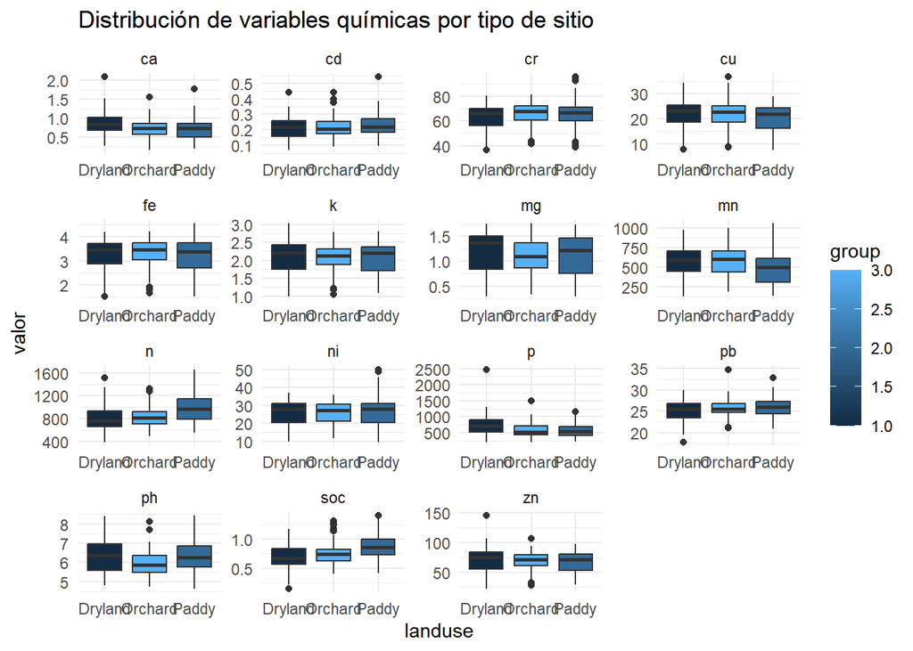

```r
wu %>%
  pivot_longer(cols = ca:p, names_to = "variable", values_to = "valor") %>%
  ggplot(aes(x = landuse, y = valor, fill = group)) +
  geom_boxplot() +
  facet_wrap(~variable, scales = "free") +
  theme_minimal() +
  labs(title = "Distribución de variables químicas por tipo de sitio")
```

Como se puede observar en los boxplots, no hay una diferencia muy marcada entre los tipos de suelo.

```r
wu_log <- wu%>%
  mutate(across(ca:p,~log1p(.)))
boxM(wu_log[, 1:15],wu_log$landuse)
```

```
##
##  Box's M-test for Homogeneity of Covariance Matrices
##
## data:  wu_log[, 1:15]
## Chi-Sq (approx.) = 561.89, df = 240, p-value < 2.2e-16
```

```r
cor(wu_log[,1:15])
```

```
##              ca         cr          cu         fe         mn         pb
## ca   1.00000000 0.50252415  0.67000321  0.6909260  0.7216366 0.19968229
## cr   0.50252415 1.00000000  0.84283031  0.8688005  0.5899014 0.64566607
## cu   0.67000321 0.84283031  1.00000000  0.9036713  0.7240404 0.62641240
## fe   0.69092596 0.86880050  0.90367129  1.0000000  0.7823704 0.63105652
## mn   0.72163658 0.58990137  0.72404041  0.7823704  1.0000000 0.33780667
## pb   0.19968229 0.64566607  0.62641240  0.6310565  0.3378067 1.00000000
## zn   0.73680006 0.76263024  0.89341991  0.8778740  0.7272234 0.58870438
## cd   0.41398463 0.48300678  0.51504912  0.4637479  0.3712434 0.48676978
## mg   0.80861151 0.78664583  0.88212995  0.9181653  0.7944323 0.46980051
## ni   0.67666798 0.89658859  0.88838544  0.9276129  0.7197094 0.60812909
## soc -0.24198395 0.02386799 -0.05731977 -0.1109147 -0.3397722 0.31142085
## ph   0.68604230 0.30559455  0.34626026  0.3467812  0.3833969 0.02401099
## n   -0.07433016 0.25022341  0.17487275  0.1507256 -0.1841986 0.49979916
## k    0.71196428 0.73488712  0.81281581  0.8439561  0.7256028 0.49389786
## p    0.47255232 0.25199116  0.46599716  0.3632056  0.3984443 0.20227015
##            zn        cd          mg         ni         soc          ph
## ca  0.7368001 0.4139846  0.80861151  0.6766680 -0.24198395  0.68604230
## cr  0.7626302 0.4830068  0.78664583  0.8965886  0.02386799  0.30559455
## cu  0.8934199 0.5150491  0.88212995  0.8883854 -0.05731977  0.34626026
## fe  0.8778740 0.4637479  0.91816529  0.9276129 -0.11091466  0.34678116
## mn  0.7272234 0.3712434  0.79443234  0.7197094 -0.33977224  0.38339690
## pb  0.5887044 0.4867698  0.46980051  0.6081291  0.31142085  0.02401099
## zn  1.0000000 0.6237927  0.88677133  0.8520615  0.01314120  0.39325552
## cd  0.6237927 1.0000000  0.48923641  0.5061491  0.24639184  0.32376314
## mg  0.8867713 0.4892364  1.00000000  0.9173519 -0.17365465  0.47696858
## ni  0.8520615 0.5061491  0.91735187  1.0000000 -0.10287662  0.43389248
## soc 0.0131412 0.2463918 -0.17365465 -0.1028766  1.00000000 -0.09843059
## ph  0.3932555 0.3237631  0.47696858  0.4338925 -0.09843059  1.00000000
## n   0.2423601 0.4255001  0.07504014  0.1684119  0.72153974 -0.04143131
## k   0.8412154 0.4808903  0.91854152  0.8687851 -0.13138792  0.44908508
## p   0.5587763 0.2973775  0.42535674  0.3151308 -0.04212079  0.14824600
##               n           k           p
## ca  -0.07433016  0.71196428  0.47255232
## cr   0.25022341  0.73488712  0.25199116
## cu   0.17487275  0.81281581  0.46599716
## fe   0.15072565  0.84395612  0.36320562
## mn  -0.18419861  0.72560276  0.39844425
## pb   0.49979916  0.49389786  0.20227015
## zn   0.24236009  0.84121543  0.55877633
## cd   0.42550008  0.48089028  0.29737747
## mg   0.07504014  0.91854152  0.42535674
## ni   0.16841194  0.86878509  0.31513084
## soc  0.72153974 -0.13138792 -0.04212079
## ph  -0.04143131  0.44908508  0.14824600
## n    1.00000000  0.08817401  0.03914037
## k    0.08817401  1.00000000  0.40872763
## p    0.03914037  0.40872763  1.00000000
```

```r
vif(lm(ca~cd+cr+cu+fe+mg+mn+ni+pb+zn+ph+n+p+k+soc,data=wu_log))
```

```
##        cd        cr        cu        fe        mg        mn        ni        pb
##  2.197181  7.250815  9.003745 16.900435 19.269990  4.144384 15.824322  3.287807
##        zn        ph         n         p         k       soc
## 11.111651  1.581243  3.077291  1.846759  7.183131  2.577006
```

Ninguno de los supuestos se cumple aún haciendo una transformación logarítmica, no hay homogeneidad de varianzas y existe multicolinearidad lo que indica que los datos no son independientes entre si.

```r
mano_vita<-manova(cbind(ca,cr,cu,fe,mn,pb,zn,cd,mg,ni,soc,ph,n,k,p)~landuse,data=wu_log)
summary(mano_vita,test="Pillai")
```

```
##            Df  Pillai approx F num Df den Df    Pr(>F)
## landuse     2 0.49537   6.2335     30    568 < 2.2e-16 ***
## Residuals 297
## ---
## Signif. codes:  0 '***' 0.001 '**' 0.01 '*' 0.05 '.' 0.1 ' ' 1
```

```r
summary.aov(mano_vita)
```

[output not shown]

[output cut: 33 more lines]

[output not shown]